# Import libraries

### Violin plot

- Violin plots are a valuable tool in data visualization used to depict data distributions. They offer a detailed representation of the probability density of a dataset, revealing where data is concentrated and how it spreads across its range. Additionally, they excel at comparing multiple data distributions, making them ideal for identifying differences or similarities between various categories or groups.
- In this task, violin plots can effectively uncover skewness and the presence of multiple peaks (multimodality) in the data, providing insights into the underlying patterns and characteristics of the dataset.

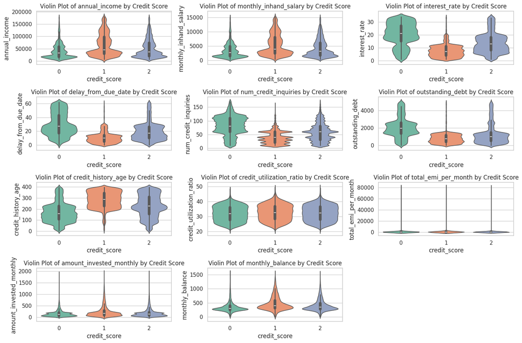

```python
sns.set(style="whitegrid")
plt.figure(figsize=(15, 10))

# List of feature names
features = [
    "annual_income", "monthly_inhand_salary", "interest_rate", "delay_from_due_date",
    "num_credit_inquiries", "outstanding_debt", "credit_history_age",
    "credit_utilization_ratio", "total_emi_per_month", "amount_invested_monthly", "monthly_balance"
]

# Create subplots for each feature using a loop
for i, feature in enumerate(features):
    plt.subplot(4, 3, i + 1)
    sns.violinplot(data=transformed_df, x='credit_score', y=feature, palette="Set2")
    plt.title(f"Violin Plot of {feature} by Credit Score")

# Adjust layout
plt.tight_layout()

# Show the plot
plt.show()
```

Based on the visual depiction of the violin plots for all the features, it becomes evident that the data distribution for each of these variables tends to exhibit substantial skewness and reveals the presence of multiple peaks, implying that the dataset is not normally distributed and may be influenced by various underlying factors. This critical insight underscores the significance of preprocessing the data, as it underscores the need to address non-normality, potentially through transformations or scaling techniques, in order to ensure that the data conforms more closely to the assumptions of statistical models and machine learning algorithms, ultimately leading to more accurate and robust model predictions.